# Milestone Report - Word Prediction

Braian Dias

October 28, 2017

# Introduction

The main purpose of this report is to present an approach to the problem of predicting the next word given n-first words in a text. This could be used, for instance, to predict the next word in a smart keyboard that we naturally use in our everyday lives.

To do so, a large corpus of text documents has been used, containing text from newspappers, blogs and Twitter in four different languages: English, German, Russian and Finnish.

The model chosen to accomplish the task was the [“n-gram”](https://en.wikipedia.org/wiki/N-gram) model, which is a type of probabilistic languague model for predicting the next item in such a sequence in the form of a (n-1)-order Markov Model.

In the next sections of the document it will be presented the basic structure of the raw data, how it could be transformed to be suitable for use in a predictive text model and the future plans to address the text prediction problem.

# Loading data

The [full dataset](https://d396qusza40orc.cloudfront.net/dsscapstone/dataset/Coursera-SwiftKey.zip) is a compressed file of approximatedly 574MB, containing raw text from newspappers, blogs and Twitter in four different languages: English, German, Russian and Finnish. For instance, The size of the English file with newspapper texts is 205MB uncompressed. Therefore, to be able to run this report in a small fraction of time, a sample of the data will be used.

The R function used to create a sample takes as input the file name, the number of lines that would be read, and the probability of reading a line (where 1 means all lines would be read, 0.5 means only 50% of the the lines will be read, and so on). The function itself will not be shown here for the sake of simplicity, but it can be seen in the file “functions.R”, function “sample_text_file” on my [github](https://github.com/bodias/datasciencecoursera/blob/master/capstone_project/functions.R) .

For demonstration purposes, a ten percent sample of the English texts will be used in this report.

```r
#load basic libraries for text handling
library(tm)
library(tokenizers)

#read sample files previously generated
en_US.blogs.sample <- readLines("sample/en_US/en_US.blogs.txt")
en_US.news.sample <- readLines("sample/en_US/en_US.news.txt")
en_US.twitter.sample <- readLines("sample/en_US/en_US.twitter.txt")

all_texts <- c(en_US.blogs.sample,en_US.news.sample,en_US.twitter.sample)
```

After reading the data, some transformations and cleaning processes were applied :

- Map “/”,“@”,“_" and “|” to white space
- Make all words lowercase
- Remove numbers
- Remove extra white spaces

```r
all_texts <- gsub("/", " ", all_texts)
all_texts <- gsub("@", " ", all_texts)
all_texts <- gsub("_{2,}", " ", all_texts)
all_texts <- gsub("\\|", " ", all_texts)
all_texts <- tolower(all_texts)
all_texts <- gsub("(\\s+[0-9]+\\s+)", " ", all_texts)
all_texts <- gsub("\\s+", " ", all_texts)
```

The next step will be tokenize the tidy raw texts into words, to extract features from data, such as frequency and n-grams.

```r
tokens <- unlist(tokenize_words(all_texts))
tokens.df <- data.frame(table(tokens))
names(tokens.df) <- c('word','frequency')
#make a copy of the dataset ordered by frequency to easily extract the most frequent words later
tokens.sorted <- tokens.df[order(-tokens.df$frequency),]
```

# Exploratory Data Analysis

After loading and transforming the raw text, some simple statistics are presented below to give a better understand of the data.

### Summary statistics

```r
summary(tokens.sorted)
```

```
##       word          frequency
##  ƒ      :     1   Min.   :     1.0
##  ɐ      :     1   1st Qu.:     1.0
##  ˍ      :     1   Median :     1.0
##  お     :     1   Mean   :    52.9
##  に     :     1   3rd Qu.:     4.0
##  い     :     1   Max.   :479120.0
##  (Other):192725
```

```r
head(tokens.sorted,10)
```

```
##        word frequency
## 169336  the    479120
## 171726   to    276770
## 17216   and    242340
## 12016     a    239036
## 123674   of    201604
## 87409    in    165863
## 85594     i    164791
## 68299   for    110412
## 90176    is    107990
## 169217 that    104656
```

```r
tail(tokens.sorted,10)
```

```
##          word frequency
## 192720     長         1
## 192721     間         1
## 192722   間隔         1
## 192723   除了         1
## 192724   隔了         1
## 192725 難しい         1
## 192726     靺         1
## 192727     鞨         1
## 192728     頭         1
## 192731   高速         1
```

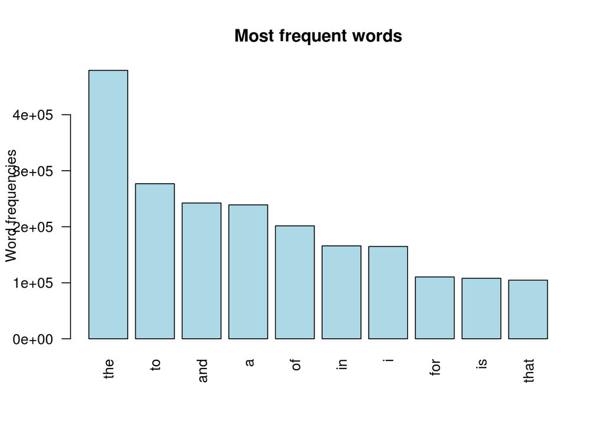

```r
barplot(tokens.sorted[1:10,]$frequency, las = 2, names.arg = tokens.sorted[1:10,]$word,
        col ="lightblue", main ="Most frequent words",
        ylab = "Word frequencies")
```

We can see that, based on the output of the **summary** function :

- There are a lot of characters that doesn’t carry any information and also foreign characters. However, they appear with a low frequency.
- Most of the frequent words are above the 3rd quantile, which leads to a conclusion that the most frequent words represents a small percentage of the data (less than 25%)

Looking at the data presented by the function **head** and the **barplot** above is possible to see the ten most frequent words. The **tail** function displays the 10-least frequent words.

Below it’s a usefull visual representation of the words, called wordcloud. It displays the 50-most frequent words.

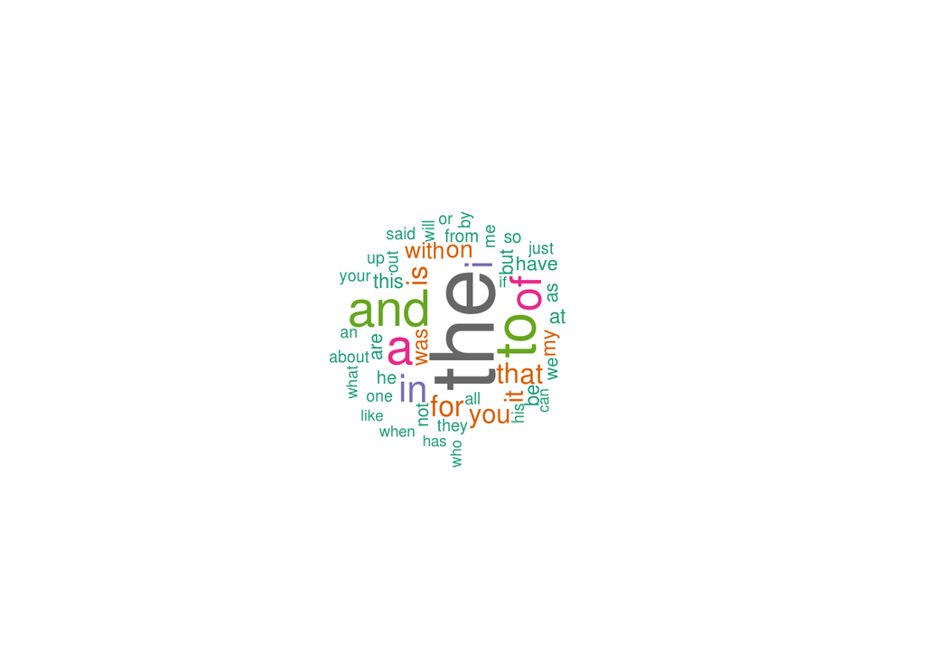

```r
library(wordcloud)
set.seed(1234)
wordcloud(words = tokens.sorted$word, freq = tokens.sorted$frequency, min.freq = 10000,
           max.words=50, random.order=FALSE, rot.per=0.35,
           colors=brewer.pal(8, "Dark2"))
```

After investigate the most and least frequent words, it’s possible to see there are improvements to be made to make the dataset smaller but more robust. To do so, the least frequent words will be removed from the original text, before generating the 2-grams and 3-grams.

```r
least_frequent_words <- tokens.sorted[tokens.sorted$frequency <= 20,"word"]
all_texts_freq <- all_texts
i <- 1
i_next <- 1
step <- 1000
# I had to iterate over a chunk of words, once "removeWords" concatenates all the words and it was
# causing an error.
while (i <= length(least_frequent_words)){
  if((i+step) > length(least_frequent_words)){
    i_next <- length(least_frequent_words)
  } else {
    i_next <- (i+step)
  }
  all_texts_freq <- removeWords(all_texts_freq,least_frequent_words[i:i_next])
  i <- i_next + 1
  #print(paste("step : ",i))
}
#remove spaces introduced by removeWords()
all_texts_freq <- gsub("\\s+", " ", all_texts_freq)

# creating the 2-grams now with the cleaned text
n2grams <- unlist(tokenize_ngrams(all_texts_freq, n=2))
n2grams.df <- data.frame(table(n2grams))
names(n2grams.df) <- c('ngram','frequency')
#make a copy of the dataset ordered by frequency to easily extract the most frequent words later
n2grams.sorted <- n2grams.df[order(-n2grams.df$frequency),]

# creating the 3-grams
n3grams <- unlist(tokenize_ngrams(all_texts_freq, n=3))
n3grams.df <- data.frame(table(n3grams))
names(n3grams.df) <- c('ngram','frequency')
#make a copy of the dataset ordered by frequency to easily extract the most frequent words later
n3grams.sorted <- n3grams.df[order(-n3grams.df$frequency),]
```

Below are the summary statistics of the n-grams

**2-gram**

```r
summary(n2grams.sorted)
```

```
##      ngram           frequency
##  い ん  :      1   Min.   :    1.000
##  を お  :      1   1st Qu.:    1.000
##  て き  :      1   Median :    1.000
##  き て  :      1   Mean   :    3.356
##  お わ  :      1   3rd Qu.:    2.000
##  ご ざ  :      1   Max.   :16138.000
##  (Other):2243118
```

```r
head(n2grams.sorted,5)
```

```
##          ngram frequency
## 1986557  to be     16138
## 952530    in a     12084
## 1002709   is a     10319
## 1024129 it was      9626
## 1329397   of a      8476
```

**3-gram**

```r
summary(n3grams.sorted)
```

```
##       ngram           frequency
##  て き て:      1   Min.   :   1.000
##  ご ざ い:      1   1st Qu.:   1.000
##  だ っ た:      1   Median :   1.000
##  っ た の:      1   Mean   :   1.327
##  た の に:      1   3rd Qu.:   1.000
##  ひ ど か:      1   Max.   :1789.000
##  (Other) :5359103
```

```r
head(n3grams.sorted,5)
```

```
##               ngram frequency
## 4613921     to be a      1789
## 1784055 going to be      1718
## 2389946   i want to      1455
## 2379446    it was a      1378
## 459322   as well as      1352
```

### Findings

There are some drawbacks in using samples instead of the whole files, the vocabulary is smaller and some very specific words may disapear because they become rare in the dataset. Using the whole files would make the vocabulary richer, but it would consume too much memory. This trade-off should be taken into consideration when generating the final model.

Also, it is possible to see that some misspelled words are naturally removed from the texts when performing the filter by the least frequent words.

# Next steps

By having the number of occurences of each 2-gram and 3-gram throughout the English texts, it’s possible to determine the most likely word to appear given a set of words. For example, according to the data, the three most likely words to appear after the words **“love my”** are : **friends**, **family** and **life**:

```r
head(n3grams.sorted[grep("^love my",n3grams.sorted$ngram),],3)
```

```
##                   ngram frequency
## 2654688 love my friends        16
## 2654673  love my family        14
## 2654724    love my life        10
```

With these frequencies, it’s possible to predict the next most likely word to occur in a sentence.

Having said that, the next steps would be :

1. Improve the algoritm to remove foreign characters;
2. Determine which size of the n-gram model would have the best accuracy;
3. Apply the same approach to German, Russian and Finnish texts.
4. Use the algorithm to create a Shiny app that could be used for everyone to predict the next word given a text.